# Árboles, bosques, k-vecinos (y más)

Carlos J. Gil Bellosta

2016-02-13

# Una matriz de conceptos entrelazados

# Una matriz de conceptos entrelazados

- Dos problemas distintos (y conocidos):
  - Regresión
  - Clasificación
- Tres modelos: árboles, bosques y k-vecinos
- Varios mecanismos para comparar modelos:
  - Validación y prueba
  - Jackknife
  - Validación cruzada

# Regresión y clasificación

# Regresión

- La variable objetivo es continua
- Una función de pérdida razonables es el RMSE (*root mean squared error*), la raíz cuadrada de
  $$\frac{1}{n} \sum_1^n (y_i - f(x_i))^2$$
- El *mejor* modelo es el que tenga el menor RMSE (generalmente)
- En usos concretos hay funciones de error mejores que el RMSE que optimizar
- La regresión lineal resuelve problemas de regresión

# Clasificación

- La variable objetivo es categórica (frecuentemente, binaria)
- Una función de pérdida razonable es el porcentaje de error (predicciones fallidas)
- La regresión logística resuelve problemas de clasificación (binaria)

# Matriz de confusión

- La matriz de confusión no es estadística
- Es pura teoría de la decisión
- Imagina que tienes un modelo para detectar fraude (clasificar fraude/no fraude)
- El modelo asigna a cada $i$ una probabilidad (o *score*) $p_i$.
- Alguien decide que el punto de corte óptimo es $p$:
  - Si $p_i \ge p$, fraude.
  - Si $p_i < p$, no fraude.
- Entonces se puede crear una tabla con valores reales / predichos

# Curva ROC

- Vale para clasificación binaria
- Compara, para cada punto de corte $p$, las tasas de falsos positivos y verdaderos positivos

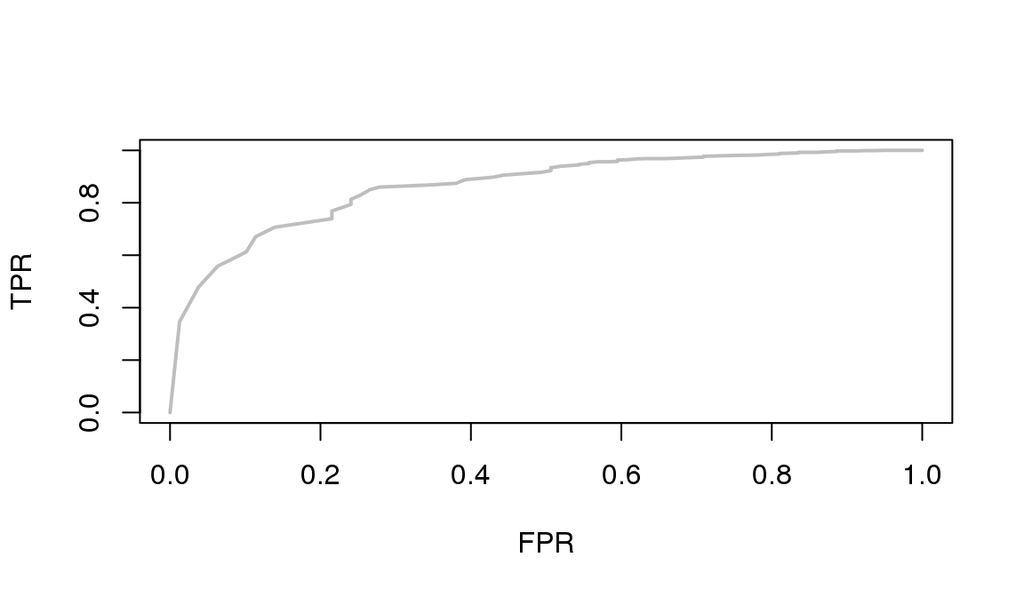

# Árboles, bosques y k-vecinos

# Árboles

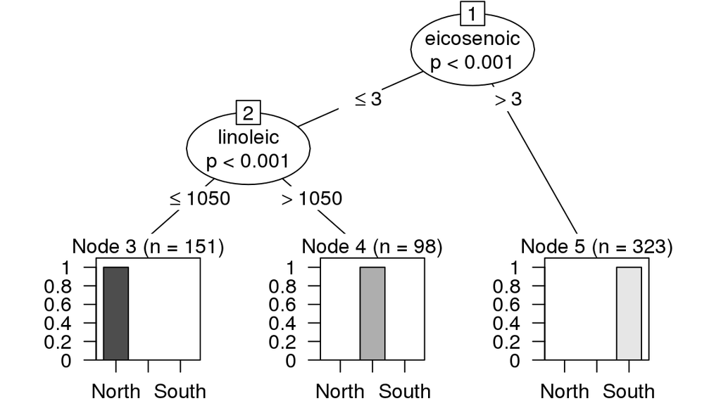

# Árboles: ventajas y desventajas

- Ventajas:
  - Valen tanto para clasificación como para regresión
  - Máxima interpretabilidad (de hecho, son casi estadística descriptiva)
  - Sencillos de usar
  - Casi sin teoría detrás
- Desventajas:
  - Baja eficacia
  - Demasiado simples
  - Problemas con predictores categóricos de muchos niveles

# Bosques aleatorios

- Son colecciones de árboles sobre los mismos datos
- Es una versión del *bagging*
- El modelo funciona por consenso democrático entre los árboles:
  - Clasificación: clase más *votada*
  - Regresión: promedio de predicciones de los árboles

# Bosques: ventajas y desventajas

- Ventajas:
  - Sencillos de usar
  - Casi sin teoría detrás
  - Gran poder predictivo (de lo mejor)
- Desventajas:
  - Nula interpretabilidad
  - Problemas con *big data* (aunque depende de la implementación)
  - Problemas con las predictores categóricos de muchos niveles

# K-vecinos

- Basados en distancias entre puntos (con los problemas que tienen las distancias)
- Para predecir en $x$, se buscan los $k$ puntos más próximos y la predicción es el consenso de dichos vecinos
- Son parecidos a los árboles, solo que, en lugar de que el modelo *predefina* regiones, cada punto define la suya

# K-vecinos: ventajas y desventajas

- Ventajas:
  - Conceptualmente simples
  - Modelos muy locales (válidos para datos muy complejos)
  - En un porcentaje sustancial de problemas, el mejor algoritmo
- Inconvenientes:
  - El modelo contiene todos los datos
  - Nula interpretabilidad
  - Problemas para definir las distancias
  - Generalmente, hay que implementarlo *a mano*

# Mecanismos para comparar modelos

# Sobreajuste

- Los datos tienen señal y ruido
- Un modelo *bueno* captura la señal e ignora el ruido
- Un modelo demasiado complicado *aprende* el ruido y no *generaliza* bien
- Un modelo demasiado complicado:
  - k-vecinos con `k = 1`
  - Un árbol cuyos nodos finales tienen 1 elemento

# Un modelo sobreajustado

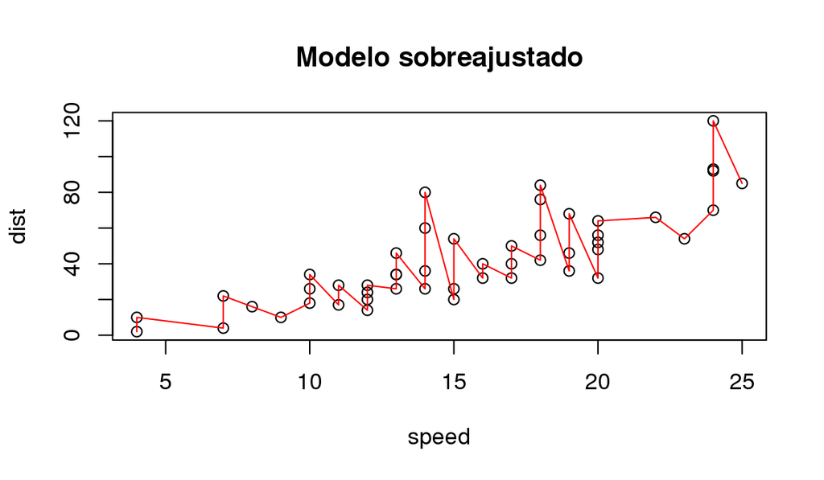

# Un modelo demasiado simple

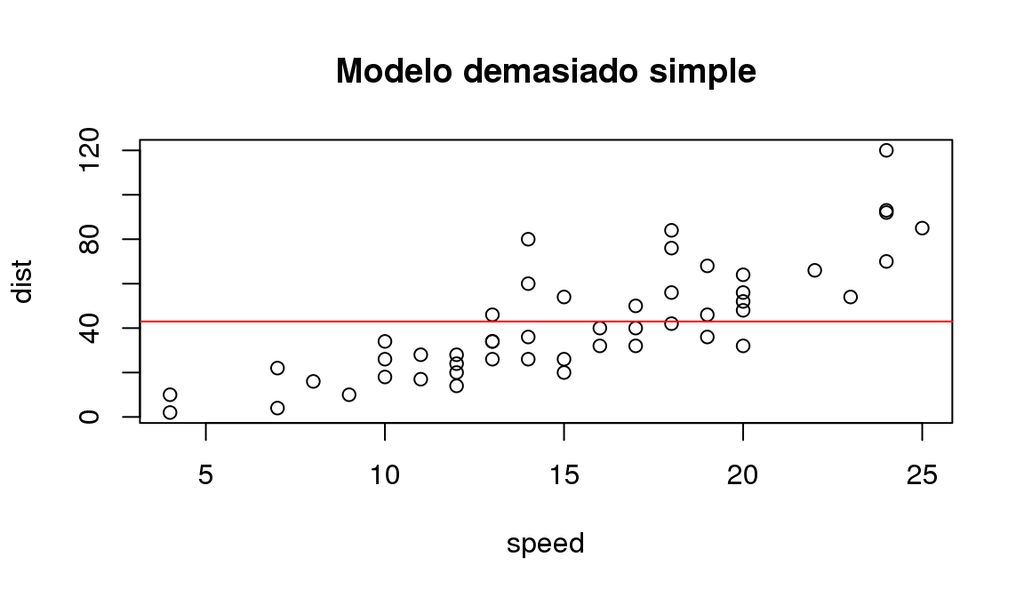

# Pero…

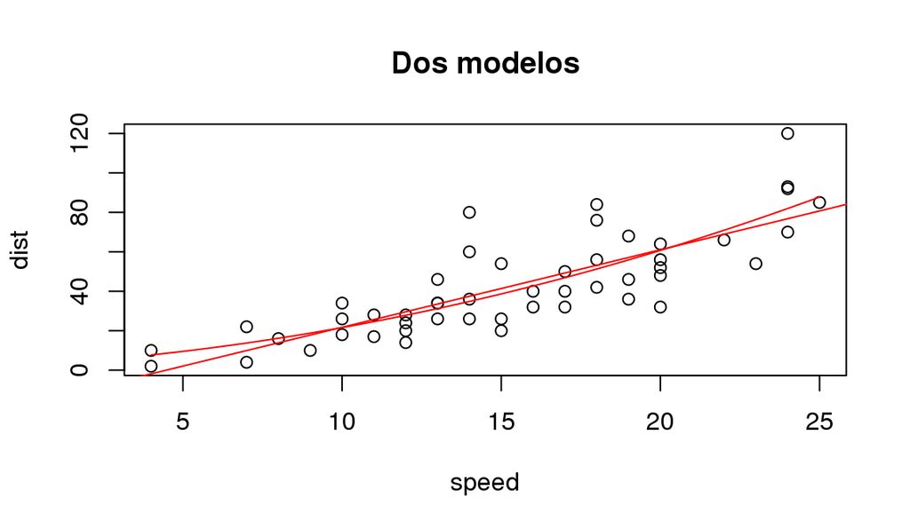

# Entrenamiento y validación

- No nos interesa el comportamiento del modelo en los datos de entrenamiento
- Nos interesa ver qué tal se comporta sobre un conjunto de datos nuevo (no usado en entrenamiento)
- Para comparar dos modelos se hace lo siguiente:
  - Se entrenan sobre un subcojunto de los datos (entrenamiento)
  - Se compara su función de pérdida en el complementario (validación)

# Jacknife

- Se usa un conjunto de entrenamiento de tamaño `n-1` y uno de validación de tamaño 1
- Pero se usan n conjuntos de entrenamiento distintos
- Es decir: se predice cada observación usando el modelo construido con el resto
- Al final se tiene la predicción en cada observación
- Ventajas:
  - No importa el tamaño del conjunto de entrenamiento y validación
  - Se obtienen predicciones en cada observación
- Desventajas:
  - Hay que ajustar el modelo n veces
  - Cada uno de los modelos son demasaido similares entre sí

# Validación cruzada (cv)

- Es como el *jackknife*, pero:
  - En lugar de usar solo una observación para validación…
  - … se usa, p.e., el 10%
- Es superior al *jacknife* por varios motivos:
  - Es más eficiente (menos iteraciones de ajuste)
  - Los modelos creados son menos iguales entre sí